# Homework 7

Zoe Portlas

October 10, 2018

## Hypothesis

Centaurea jacea, C. nigra, and C. x moncktonii are all part of the hybrid complex. I hypothesize that if the capitulum of C. jacea is wider than the capitulum of C. nigra, that their hybrid, C. x monktonii, will be intermediate between them.

## The Data

There are 3 groups: jacea, nigra, and monck. The measurement of interest is the width of the capitulum (cm).

I want to have a large number of samples for each group because the experiment design would probably include sampling different populations in New England and each population would have 10 samples. For this reason, I’m going to have 1000 samples. According to previous work, the hybrid has overtaken its parent species in the Pacific Northwest, but not in New England. Because of those observations, I’m going to divide the 1000 samples fairly evenly between the groups.

The reported range of widths for C. jacea is 3 - 4.5 cm and the reported range of widths for C. nigra is 2 - 3 cm. Here, jacea will have the mean 3.75 cm and nigra will have the mean 2.5 cm. My hypothesis is that monck is intermediate, it will have a mean of 3.1 cm. I’m going to assume for the standard deviation that most samples will be within 0.6 - 0.75 cm of the mean because then they would still be similar to the ranges I found for the parent species.

#### Making the data

```r
nGroups <- 3
nName <- c("jacea", "nigra", "monck")
nSize <- c(325,325,350)
nMean <- c(3.75, 2.5, 3.1)
nSD <- c(0.75,0.65,0.7)
```

#### Organizing the data into a data frame

```r
ID <- 1:sum(nSize)

width <- c(rnorm(n = nSize[1], mean = nMean[1], sd = nSD[1]),
            rnorm(n = nSize[2], mean = nMean[2], sd = nSD[2]),
            rnorm(n = nSize[3], mean = nMean[3], sd = nSD[3]))
TGroup <- rep(nName, nSize)
table(TGroup)
```

```
## TGroup
## jacea monck nigra
##   325   350   325
```

```r
ANOdata <- data.frame(ID, TGroup, width)
str(ANOdata)
```

```
## 'data.frame':    1000 obs. of  3 variables:
##  $ ID    : int  1 2 3 4 5 6 7 8 9 10 ...
##  $ TGroup: Factor w/ 3 levels "jacea","monck",..: 1 1 1 1 1 1 1 1 1 1 ...
##  $ width : num  3.7 4.26 2.18 3.44 3.82 ...
```

```r
head(ANOdata)
```

```
##   ID TGroup    width
## 1  1  jacea 3.696621
## 2  2  jacea 4.257670
## 3  3  jacea 2.183715
## 4  4  jacea 3.438396
## 5  5  jacea 3.821642
## 6  6  jacea 2.720154
```

#### Running an ANOVA

```r
ANOmodel <- aov(width ~ TGroup, data = ANOdata)
print(ANOmodel)
```

```
## Call:
##    aov(formula = width ~ TGroup, data = ANOdata)
##
## Terms:
##                   TGroup Residuals
## Sum of Squares  261.3148  516.8912
## Deg. of Freedom        2       997
##
## Residual standard error: 0.7200323
## Estimated effects may be unbalanced
```

```r
print(summary(ANOmodel))
```

```
##              Df Sum Sq Mean Sq F value Pr(>F)
## TGroup        2  261.3  130.66     252 <2e-16 ***
## Residuals   997  516.9    0.52
## ---
## Signif. codes:  0 '***' 0.001 '**' 0.01 '*' 0.05 '.' 0.1 ' ' 1
```

#### Plotting the ANOVA with ggplot

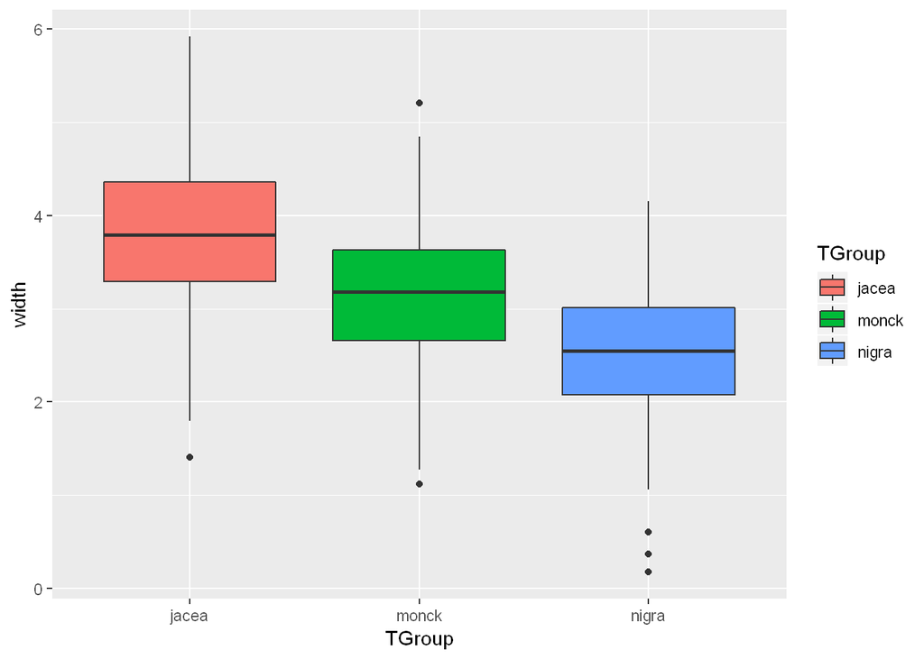

```r
ANOPlot <- ggplot(data = ANOdata,
                  aes(x = TGroup, y = width,
                      fill = TGroup)) +
            geom_boxplot()
print(ANOPlot)
```

```r
nGroups <- 3
nName <- c("jacea", "nigra", "monck")
nSize <- c(5,5,5)
nMean <- c(3.75, 2.5, 3.1)
nSD <- c(0.75,0.65,0.7)

ID <- 1:sum(nSize)

width <- c(rnorm(n = nSize[1], mean = nMean[1], sd = nSD[1]),
            rnorm(n = nSize[2], mean = nMean[2], sd = nSD[2]),
            rnorm(n = nSize[3], mean = nMean[3], sd = nSD[3]))
TGroup <- rep(nName, nSize)
table(TGroup)
```

```
## TGroup
## jacea monck nigra
##     5     5     5
```

```r
ANOdata <- data.frame(ID, TGroup, width)
str(ANOdata)
```

```
## 'data.frame':    15 obs. of  3 variables:
##  $ ID    : int  1 2 3 4 5 6 7 8 9 10 ...
##  $ TGroup: Factor w/ 3 levels "jacea","monck",..: 1 1 1 1 1 3 3 3 3 3 ...
##  $ width : num  4.54 4.22 2.15 3.78 4.17 ...
```

```r
head(ANOdata)
```

```
##   ID TGroup    width
## 1  1  jacea 4.541407
## 2  2  jacea 4.219662
## 3  3  jacea 2.154504
## 4  4  jacea 3.783786
## 5  5  jacea 4.172184
## 6  6  nigra 2.314873
```

```r
ANOmodel <- aov(width ~ TGroup, data = ANOdata)
print(ANOmodel)
```

```
## Call:
##    aov(formula = width ~ TGroup, data = ANOdata)
##
## Terms:
##                   TGroup Residuals
## Sum of Squares  4.355113  9.700853
## Deg. of Freedom        2        12
##
## Residual standard error: 0.8991131
## Estimated effects may be unbalanced
```

```r
print(summary(ANOmodel))
```

```
##             Df Sum Sq Mean Sq F value Pr(>F)
## TGroup       2  4.355  2.1776   2.694  0.108
## Residuals   12  9.701  0.8084
```

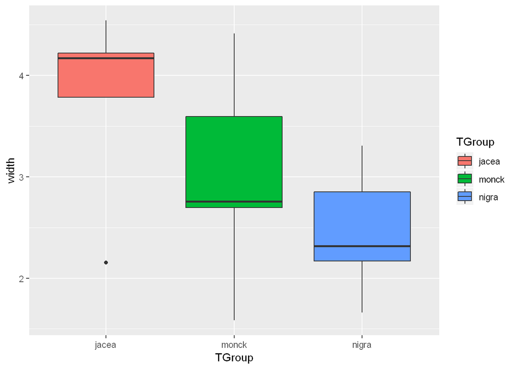

```r
ANOPlot <- ggplot(data = ANOdata,
                  aes(x = TGroup, y = width,
                      fill = TGroup)) +
            geom_boxplot()
print(ANOPlot)
```

### Adjusting the sample sizes of the groups

What if I make the sample sizes a lot smaller? Will it still be significant? How big of a sample size is still significant?

```r
nGroups <- 3
nName <- c("jacea", "nigra", "monck")
nSize <- c(48,48,48)
nMean <- c(3.2, 2.9, 3.0)
nSD <- c(0.75,0.65,0.7)

ID <- 1:sum(nSize)

width <- c(rnorm(n = nSize[1], mean = nMean[1], sd = nSD[1]),
            rnorm(n = nSize[2], mean = nMean[2], sd = nSD[2]),
            rnorm(n = nSize[3], mean = nMean[3], sd = nSD[3]))
TGroup <- rep(nName, nSize)
table(TGroup)
```

```
## TGroup
## jacea monck nigra
##    48    48    48
```

```r
ANOdata <- data.frame(ID, TGroup, width)
str(ANOdata)
```

```
## 'data.frame':    144 obs. of  3 variables:
##  $ ID    : int  1 2 3 4 5 6 7 8 9 10 ...
##  $ TGroup: Factor w/ 3 levels "jacea","monck",..: 1 1 1 1 1 1 1 1 1 1 ...
##  $ width : num  2.06 3.84 2.43 2.67 3.33 ...
```

```r
head(ANOdata)
```

```
##   ID TGroup    width
## 1  1  jacea 2.060032
## 2  2  jacea 3.840773
## 3  3  jacea 2.431243
## 4  4  jacea 2.665418
## 5  5  jacea 3.328310
## 6  6  jacea 3.184819
```

```r
ANOmodel <- aov(width ~ TGroup, data = ANOdata)
print(ANOmodel)
```

```
## Call:
##    aov(formula = width ~ TGroup, data = ANOdata)
##
## Terms:
##                   TGroup Residuals
## Sum of Squares   2.42459  67.71908
## Deg. of Freedom        2       141
##
## Residual standard error: 0.6930203
## Estimated effects may be unbalanced
```

```r
print(summary(ANOmodel))
```

```
##              Df Sum Sq Mean Sq F value Pr(>F)
## TGroup        2   2.42  1.2123   2.524 0.0837 .
## Residuals   141  67.72  0.4803
## ---
## Signif. codes:  0 '***' 0.001 '**' 0.01 '*' 0.05 '.' 0.1 ' ' 1
```

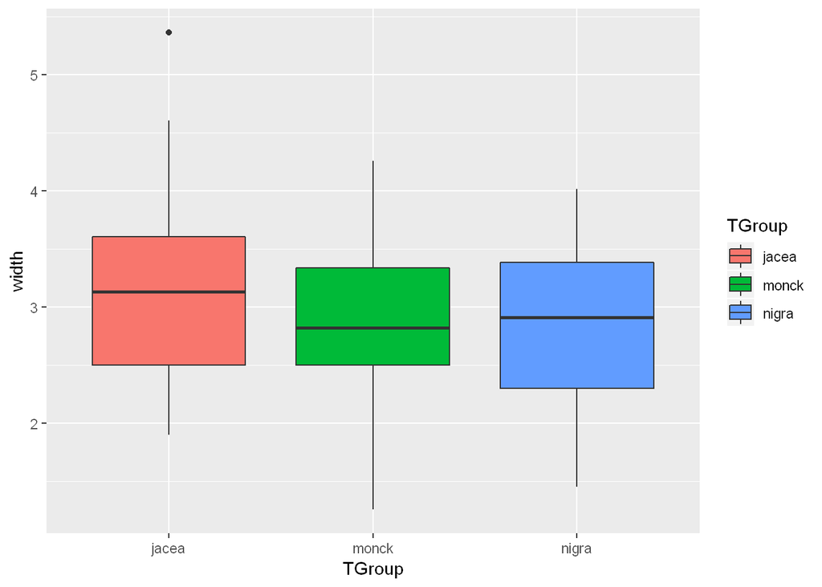

```r
ANOPlot <- ggplot(data = ANOdata,
                  aes(x = TGroup, y = width,
                      fill = TGroup)) +
            geom_boxplot()
print(ANOPlot)
```